# Data 607 Final Project presentation

2023-12-14

## Introduction

My project’s focus is manga or Japanese comic books/graphic novels.

Ever year, there are lots of manga that come out of Japan either brand-new or continuing from the years prior. While some manga succeed or stay succeeding, a lot of other manga are cancelled or left on hiatus early in its run. Not all factors that lend to this is in the hands of the people working on it.

My questions:  
- What variables make for a successful manga series?  
- Can we predict which manga series will be successful?

## Data

I got both of my datasets from Kaggle

- MyAnimeList (https://www.kaggle.com/datasets/andreuvallhernndez/myanimelist) by Andreu Vall Hernàndez. Has 64,833 rows due to having the whole website’s database of manga.
- Best-Selling Manga (https://www.kaggle.com/datasets/drahulsingh/best-selling-manga) by D Rahulsingh. A dataset of 187 manga.

## Data Cleaning - myAnimelist

```r
colnames(myanimelist_manga)
```

```
##  [1] "manga_id"          "title"             "type"
##  [4] "score"             "scored_by"         "status"
##  [7] "volumes"           "chapters"          "start_date"
## [10] "end_date"          "members"           "favorites"
## [13] "sfw"               "approved"          "created_at_before"
## [16] "updated_at"        "real_start_date"   "real_end_date"
## [19] "genres"            "themes"            "demographics"
## [22] "authors"           "serializations"    "synopsis"
## [25] "background"        "main_picture"      "url"
## [28] "title_english"     "title_japanese"    "title_synonyms"
```

## Data Cleaning - myAnimelist

```r
colnames(myanimelist_anime)
```

```
##  [1] "anime_id"         "title"            "type"             "score"
##  [5] "scored_by"        "status"           "episodes"         "start_date"
##  [9] "end_date"         "source"           "members"          "favorites"
## [13] "episode_duration" "total_duration"   "rating"           "sfw"
## [17] "approved"         "created_at"       "updated_at"       "start_year"
## [21] "start_season"     "real_start_date"  "real_end_date"    "broadcast_day"
## [25] "broadcast_time"   "genres"           "themes"           "demographics"
## [29] "studios"          "producers"        "licensors"        "synopsis"
## [33] "background"       "main_picture"     "url"              "trailer_url"
## [37] "title_english"    "title_japanese"   "title_synonyms"
```

## Data Cleaning - myAnimelist

```r
myanimelist_manga <- subset(myanimelist_manga,
                            select=c(1,2,3,4,5,6,7,8,9,10,11,12,13,19,20,21,23))
colnames(myanimelist_manga)
```

```
##  [1] "manga_id"       "title"          "type"           "score"
##  [5] "scored_by"      "status"         "volumes"        "chapters"
##  [9] "start_date"     "end_date"       "members"        "favorites"
## [13] "sfw"            "genres"         "themes"         "demographics"
## [17] "serializations"
```

```r
myanimelist_anime <- subset(myanimelist_anime,
                            select=c(1,2,3,4,5,6,7,8,9,10,11,12,15,29))
colnames(myanimelist_anime)
```

```
##  [1] "anime_id"   "title"      "type"       "score"      "scored_by"
##  [6] "status"     "episodes"   "start_date" "end_date"   "source"
## [11] "members"    "favorites"  "rating"     "studios"
```

## myAnimelist_manga

```r
head(myanimelist_manga, 1)
```

```
##   manga_id   title  type score scored_by               status volumes chapters
## 1        2 Berserk manga  9.47    319696 currently_publishing      NA       NA
##   start_date end_date members favorites  sfw
## 1 1989-08-25           643969    119470 True
##                                                                                   genres
## 1 ['Action', 'Adventure', 'Award Winning', 'Drama', 'Fantasy', 'Horror', 'Supernatural']
##                                               themes demographics
## 1 ['Gore', 'Military', 'Mythology', 'Psychological']   ['Seinen']
##     serializations
## 1 ['Young Animal']
```

## myAnimelist_manga

```r
myanimelist_manga$end_date[myanimelist_manga$end_date==""] <- NA
myanimelist_manga$demographics <-
  str_extract(myanimelist_manga$demographics, "[A-Z]+[a-z]+")
myanimelist_manga$serializations <-
  str_extract(myanimelist_manga$serializations, "[A-Z]+[a-z]+")

myanimelist_manga$title[myanimelist_manga$title=="One Punch-Man"] <-
  "One Punch Man"
```

## situations incorprating myAnimelist_anime

I ran into the problem of add some myanimelist_anime for the manga dataset.

## Solution

```r
myanimelist <- myanimelist_manga
myanimelist$anime_adaptation <- 'No'
myanimelist$anime_adaptation[myanimelist$title %in% myanimelist_anime$title] <-
  "Yes"
head(myanimelist[, c(2,18)])
```

```
##                                             title anime_adaptation
## 1                                         Berserk              Yes
## 2                                       One Piece              Yes
## 3 JoJo no Kimyou na Bouken Part 7: Steel Ball Run               No
## 4                                  Oyasumi Punpun               No
## 5                             Fullmetal Alchemist              Yes
## 6                                        Vagabond               No
```

## bestsellingmanga

I planned to join myanimelist_manga to bestsellingmanga, but it needs some cleaning first.

```r
colnames(bestsellingmanga)
```

```
## [1] "Manga.series"
## [2] "Author.s."
## [3] "Publisher"
## [4] "Demographic"
## [5] "No..of.collected.volumes"
## [6] "Serialized"
## [7] "Approximate.sales.in.million.s."
## [8] "Average.sales.per.volume.in.million.s."
```

## bestsellingmanga

```r
colnames(bestsellingmanga)[1]="title"
bestsellingmanga <-
  inner_join(bestsellingmanga, myanimelist_manga, by = "title")
#get rid of non manga rows if type != "manga" for dups
bestsellingmanga <-
  bestsellingmanga[bestsellingmanga$type == 'manga', ]
nrow(bestsellingmanga)
```

```
## [1] 99
```

```r
bestsellingmanga$anime_adaptation <- 'No'
bestsellingmanga$anime_adaptation[bestsellingmanga$title %in% myanimelist_anime$title] <-
  "Yes"
```

## bestsellingmanga

```r
head(bestsellingmanga[, c(1,25)], 15)
```

```
##                  title anime_adaptation
## 1            One Piece              Yes
## 2             Golgo 13              Yes
## 3          Dragon Ball              Yes
## 4             Doraemon              Yes
## 6               Naruto              Yes
## 8            Slam Dunk              Yes
## 9             Oishinbo              Yes
## 10              Bleach              Yes
## 12      Hajime no Ippo              Yes
## 13               Touch              Yes
## 14             Kingdom              Yes
## 15     Captain Tsubasa              Yes
## 16           Sazae-san              Yes
## 17            Vagabond               No
## 18 Fullmetal Alchemist              Yes
```

## Genres and Themes

```
## [1] "['Action','Award Winning']"
```

```
## [1] "['Vampire','School']"
```

## Genres datasets

```r
manga_genres <- data.frame(matrix(ncol=2,nrow=0))
colnames(manga_genres) <- c('title','genre')
manga_genres
```

```
## [1] title genre
## <0 rows> (or 0-length row.names)
```

```r
for (i in 1:nrow(bestsellingmanga)){
  genre_manga <-
    str_extract_all(bestsellingmanga$genres[i],
                    "[A-Za-z]+(-[A-Za-z]+)?( [A-Za-z]+ [A-Za-z]+)?( [A-Za-z]+)?")
  for(m in genre_manga){
    for(n in m){
      manga_genres[nrow(manga_genres) + 1, ] =
        c(bestsellingmanga$title[i], n)
    }
  }
}
```

## Genres datasets

```r
head(manga_genres)
```

```
##       title         genre
## 1 One Piece        Action
## 2 One Piece     Adventure
## 3 One Piece       Fantasy
## 4  Golgo 13        Action
## 5  Golgo 13     Adventure
## 6  Golgo 13 Award Winning
```

```r
nrow(manga_genres)
```

```
## [1] 295
```

## Themes dataset

```r
manga_themes <- data.frame(matrix(ncol=2,nrow=0))
colnames(manga_themes) <- c('title','theme')
manga_themes
```

```
## [1] title theme
## <0 rows> (or 0-length row.names)
```

```r
for (i in 1:nrow(bestsellingmanga)){
  theme_manga <-
    str_extract_all(bestsellingmanga$themes[i],
                    "[A-Za-z]+(-[A-Za-z]+)?( [A-Za-z]+ [A-Za-z]+)?( [A-Za-z]+)?")
  for(m in theme_manga){
    for(n in m){
      manga_themes[nrow(manga_themes) + 1, ] =
        c(bestsellingmanga$title[i], n)
    }
  }
}
```

## Themes dataset

```r
head(manga_themes)
```

```
##         title           theme
## 1    Golgo 13      Adult Cast
## 2    Golgo 13      Historical
## 3 Dragon Ball    Martial Arts
## 4 Dragon Ball     Super Power
## 5    Doraemon Anthropomorphic
## 6    Doraemon          School
```

```r
nrow(manga_themes)
```

```
## [1] 126
```

## How many of the best-selling manga have anime adaptations?

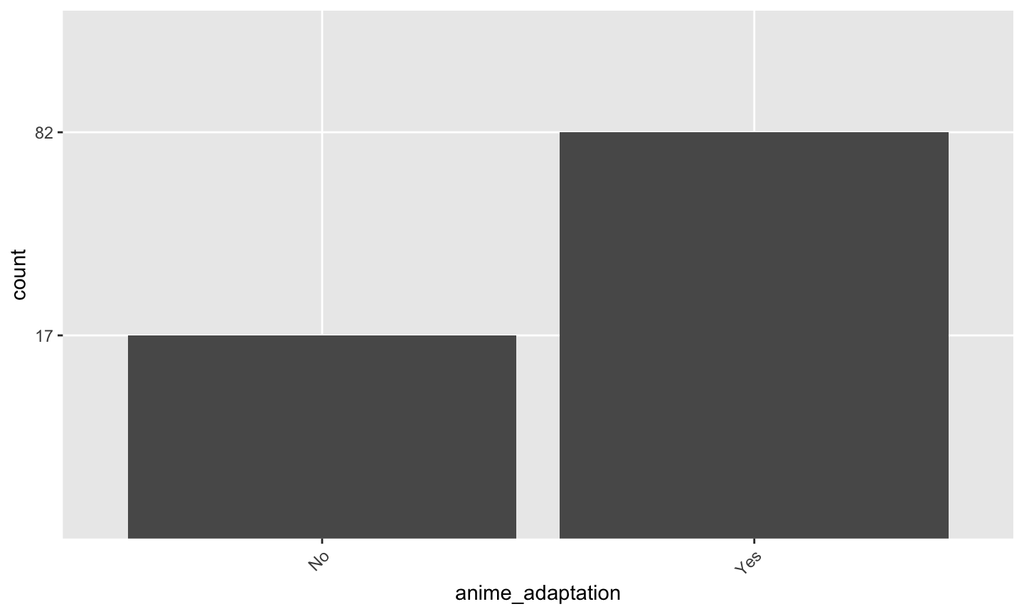

## Best-selling manga’s genres

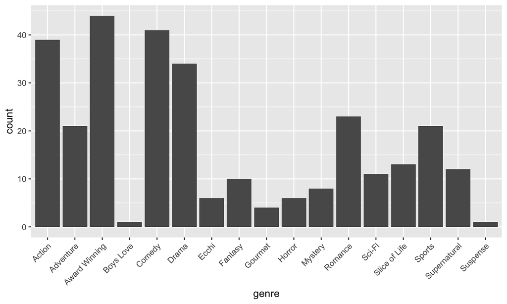

## Best-selling manga’s themes

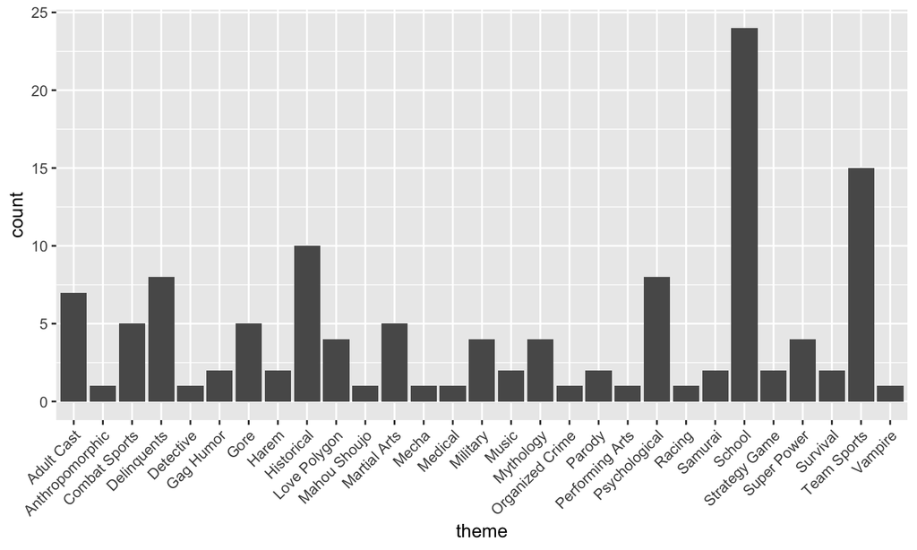

## Probabilty through sample size

```r
set.seed(49568)
samp <- myanimelist %>%
  sample_n(10)
head(samp[, c(2, 14, 15)], 5)
```

```
##                      title                                   genres
## 1        Hanazono no Kioku        ['Boys Love', 'Drama', 'Erotica']
## 2 Fudatsuki no Kyouko-chan    ['Comedy', 'Romance', 'Supernatural']
## 3    Hoshigari Love Dollar                                       []
## 4                  Ajuutan ['Action', 'Drama', 'Fantasy', 'Horror']
## 5     Busu ni Hanataba wo.                    ['Comedy', 'Romance']
##                  themes
## 1                    []
## 2 ['School', 'Vampire']
## 3                    []
## 4                    []
## 5            ['School']
```

## Genre - sample size

```r
samp_genres <- data.frame(matrix(ncol=2,nrow=0))
colnames(samp_genres) <- c('title','genre')

for (i in 1:nrow(samp)){
  t <- str_extract_all(samp$genres[i],"[A-Za-z]+(-[A-Za-z]+)?( [A-Za-z]+ [A-Za-z]+)?( [A-Za-z]+)?")
  for(m in t){
    for(n in m){
      samp_genres[nrow(samp_genres) + 1, ] = c(samp$title[i], n)
    }
  }
}
```

## Genre - sample size

```r
head(samp_genres)
```

```
##                      title        genre
## 1        Hanazono no Kioku    Boys Love
## 2        Hanazono no Kioku        Drama
## 3        Hanazono no Kioku      Erotica
## 4 Fudatsuki no Kyouko-chan       Comedy
## 5 Fudatsuki no Kyouko-chan      Romance
## 6 Fudatsuki no Kyouko-chan Supernatural
```

## Genre - sample size

```r
samp_genres$count <- 1
samp_genres_stats <- samp_genres %>% group_by(genre) %>%
  summarise(count=sum(count),
            .groups = 'drop')
samp_genres_stats <- samp_genres_stats[order(samp_genres_stats$count, decreasing = TRUE), ]
```

## Genre - sample size

```r
samp_genres_stats
```

```
## # A tibble: 11 × 2
##    genre         count
##    <chr>         <dbl>
##  1 Action            3
##  2 Romance           3
##  3 Boys Love         2
##  4 Comedy            2
##  5 Drama             2
##  6 Erotica           2
##  7 Fantasy           2
##  8 Award Winning     1
##  9 Hentai            1
## 10 Horror            1
## 11 Supernatural      1
```

## Genre - sample size

```r
t <- 0
for(x in 1:nrow(samp_genres_stats)){
  if(samp_genres_stats$genre[x] %in% head(top_genres$genre, 5)){
    t <- t + samp_genres_stats$count[x]
  }
}
print((t/sum(samp_genres_stats$count))*100)
```

```
## [1] 55
```

## Theme - sample size

```r
samp_themes <- data.frame(matrix(ncol=2,nrow=0))
colnames(samp_themes) <- c('title','theme')

for (i in 1:nrow(samp)){
  t <- str_extract_all(samp$themes[i],"[A-Za-z]+(-[A-Za-z]+)?( [A-Za-z]+ [A-Za-z]+)?( [A-Za-z]+)?")
  for(m in t){
    for(n in m){
      samp_themes[nrow(samp_themes) + 1, ] = c(samp$title[i], n)
    }
  }
}
```

## Theme - sample size

```r
head(samp_themes)
```

```
##                      title        theme
## 1 Fudatsuki no Kyouko-chan       School
## 2 Fudatsuki no Kyouko-chan      Vampire
## 3     Busu ni Hanataba wo.       School
## 4             Tonda Couple Love Polygon
## 5             Tonda Couple       School
## 6     A Handsome Swordsman Martial Arts
```

## Theme - sample size

```r
samp_themes$count <- 1
samp_themes_stats <- samp_themes %>% group_by(theme) %>%
  summarise(count=sum(count),
            .groups = 'drop')
samp_themes_stats <- samp_themes_stats[order(samp_themes_stats$count, decreasing = TRUE), ]
```

## Theme - sample size

```r
samp_themes_stats
```

```
## # A tibble: 5 × 2
##   theme        count
##   <chr>        <dbl>
## 1 School           3
## 2 Love Polygon     1
## 3 Martial Arts     1
## 4 Military         1
## 5 Vampire          1
```

## Theme - sample size

```r
t <- 0
for(x in 1:nrow(samp_themes_stats)){
  if(samp_themes_stats$theme[x] %in% head(top_themes$theme, 5)){
    t <- t + samp_themes_stats$count[x]
  }
}
print((t/sum(samp_themes_stats$count))*100)
```

```
## [1] 42.85714
```

## more samples

```
## [1] "For sample size 50's genres:"
```

```
## [1] 38
```

```
## [1] "For sample size 50's themes:"
```

```
## [1] 68.18182
```

```
## [1] "For sample size 100's genres:"
```

```
## [1] 39.89071
```

```
## [1] "For sample size 100's themes:"
```

```
## [1] 47.16981
```

## Conclusion

Anime adaptations: 17:82 for best selling mangas without/with an adaptation. (~82.82%) Genres & Themes: there are clear subject topics that a lot of the best selling mangas fall under

Next steps: I would like to dive more into testing samples using probability and test more variables that might have also be big success factors (i.e. start_date, anime_length).